# Linear SuSiE Failure

```r
library(purrr)
library(tictoc)

knitr::opts_knit$set(root.dir = '/project2/mstephens/ktayeb/logistic-susie-snakemake')
```

```r
source('workflow/scripts/fitting/fit_gibss_labf.R')

if(interactive()){
  httpgd::hgd()
}
```

```r
X <- readRDS('results/gsea/msigdb_c2_5k/X.rds')
X <- X[, sample(ncol(X), 1000, replace=F)]
X <- X[Matrix::rowSums(X) >= 5,]
X <- X[,colSums(as.matrix(X)) > 0]
```

```r
sigmoid <- function(x){1 / (1 + exp(-x))}

simulate <- function(X, beta0, beta, q, seed){
    set.seed(seed)
    n <- nrow(X)
    p <- ncol(X)

    idx <- sort(sample(p, q, replace=F))
    logit <- drop(X[, idx, drop = F] %*% rep(beta, q)) + beta0
    y <- rbinom(length(logit), 1, sigmoid(logit))
    sim <- list(idx = idx, logit = logit, y = y, n=n, p=p, X=X, beta0=beta, beta=beta, q=q)
    return(sim)
}
```

## Extreme example

Here we do a single active gene set simulations. We set the intercept to $-10$ (so that only the genes in an active gene set appear in the list). We set the effect to $10$ so that genes in the active gene set appear with probability $\frac{1}{2}$.

In this case we see that both the linear and logistic SER correctly identify the active gene set. However, linear SuSiE fails fairly dramatically.

```r
sim <- simulate(X, -10, 10, q=1, seed=42)
data <- augment(X, sim$y)

ser_fit <- with(data, susieR::susie(X, y, L=1))
susie_fit <- with(data, susieR::susie(X, y, L=5))

logistic_ser_fit <- with(data, fit_ser(X, y))
logistic_ser_fit$pip <- logistic_ser_fit$alpha

gibss_fit <- with(data, fit_gibss(X, y, L=5))
# gibss_fit$pip <- with(gibss_fit, logisticsusie::compute_pip(alpha[prior_variance > 0.01, ]))
gibss_fit$pip <- with(gibss_fit, logisticsusie::compute_pip(alpha))
```

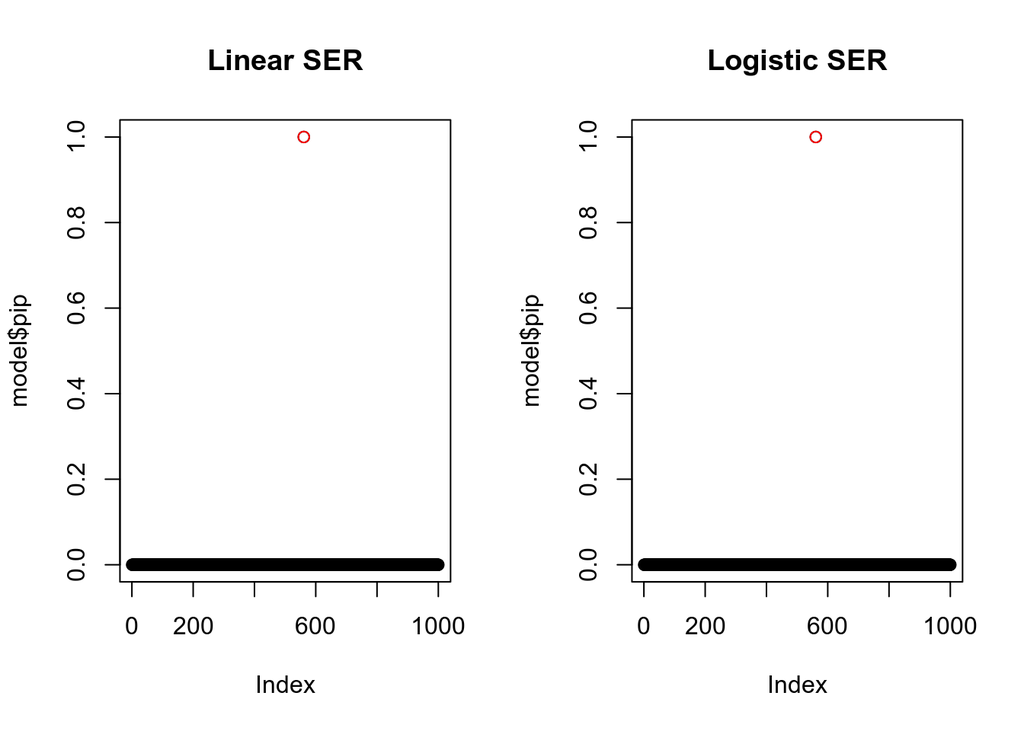

```r
plot_pips <- function(sim, model, ...){
  plot(model$pip, ...)
  points(sim$idx, model$pip[sim$idx], col='red')
}

par(mfrow=c(1,2))
plot_pips(sim, ser_fit, main='Linear SER')
plot_pips(sim, logistic_ser_fit, main='Logistic SER')
```

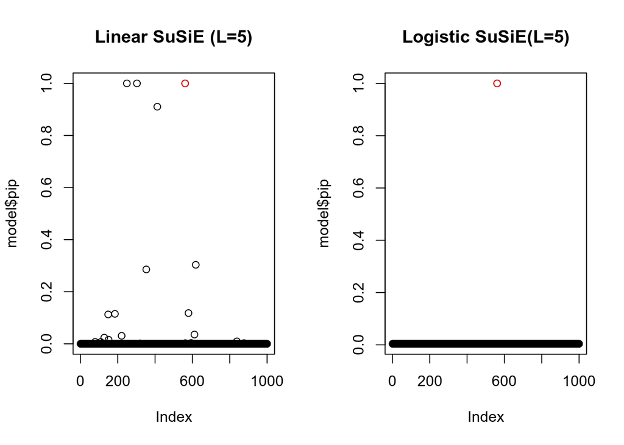

```r
plot_pips(sim, susie_fit, main='Linear SuSiE (L=5)')
plot_pips(sim, gibss_fit, main='Logistic SuSiE(L=5)')
```

While the first component correctly identifies the causal variant, it is hard to distinguish the real signal from the fals positives. For example the log BFs are large for all effects in the linear model. Furthermore, the estimated prior variance for effects 2 through 4 are only an order of magnitude smaller than the strongest (true) effect.

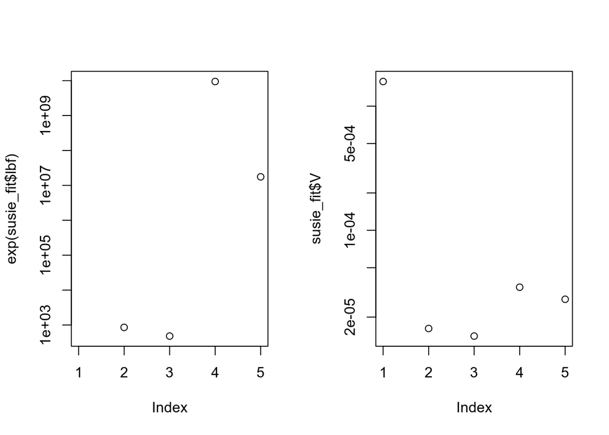

```r
par(mfrow=c(1, 2))
plot(exp(susie_fit$lbf), log='y')
plot(susie_fit$V, log='y')
```

```r
print(susie_fit$lbf)
```

```
## [1] 1440.808013    6.750451    6.178150   22.968046   16.680944
```

In contrast, the logistic SuSiE fit reports small prior variance and small BF for all but the strongest effect. Furthermore, the posterior over the effects 2-5 are very dispersed, indicating that the model is not very certain of selecting any other effects. Linear SuSiE estimates relatively smaller effects for the false positives, but does so very confidently.

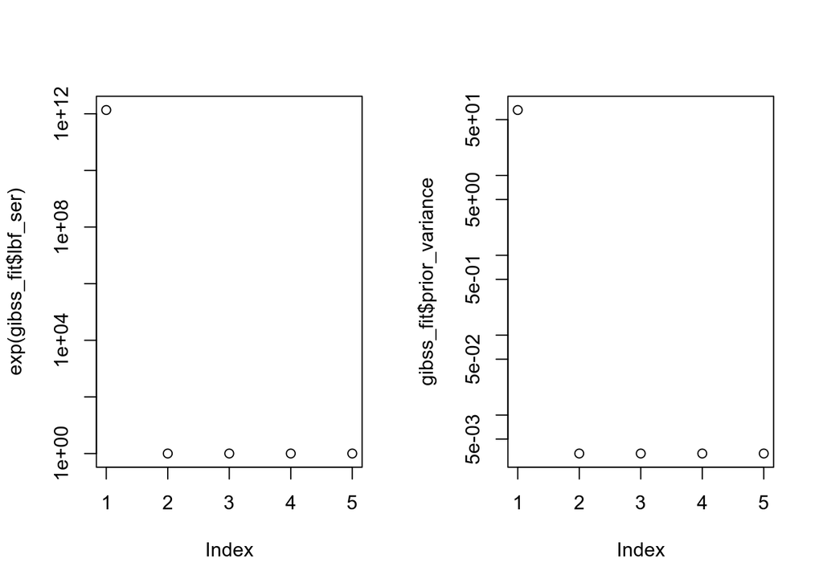

```r
par(mfrow=c(1, 2))
plot(exp(gibss_fit$lbf_ser), log='y')
plot(gibss_fit$prior_variance, log='y')
```

```r
print(gibss_fit$lbf_ser)
```

```
## [1] 27.942031860  0.002370358  0.002370358  0.002371311  0.002369404
```

Which gene sets are FP?

```r
causal_gs <- colnames(X)[sim$idx]
susie_large_pip <- names(susie_fit$pip)[susie_fit$pip > 0.9]
FP <- setdiff(susie_large_pip, causal_gs)

# intersect gs and fp
t(X[, causal_gs]) %*% X[, FP, drop=F]
```

```
##      M19439 M7012 M6051
## [1,]      7     3     1
```

```r
# overlap between gene list and FP gene sets
sim$y %*% X[, FP]
```

```
##      M19439 M7012 M6051
## [1,]      5     1     0
```

```r
with(susie_fit, colSums(mu * alpha)[causal_gs])
```

```
##     M18299
## 0.03974297
```

```r
# expected effect sizes for FPs
with(susie_fit, colSums(mu * alpha)[FP])
```

```
##       M19439        M7012        M6051
##  0.005852542 -0.005224153 -0.003651660
```

```r
# size of FP gene sets
colSums(X[, FP])
```

```
## M19439  M7012  M6051
##     22     18     10
```

Think about this: all the predictions are close to $\approx 0$. Then the MSE for $y = 1$ is $\approx 1$ and the MSE for $y = 0$ is $\approx 0$.

So we see that the log-likelihood is not very sensitive to small perturbation in $\beta$ for $y=0$ observation, but is relatively more sensitive to perturbations for $y=1$ observations.

In otherwords, we pay a lot it MSE for each $y=1$ observation, so it often pays to make small adjustments to the predictions with these FP effects.